# R Notebook

```r
library("Hmisc")
library("tidyr")
library("mice")
library("dplyr")
library("ggplot2")
library("BaylorEdPsych")
library("caret")
library("caretEnsemble")
```

Read in Sets

```r
train<-read.csv('/Users/Cam/Documents/Final Project/train.csv', header=TRUE, sep=",", na.strings = c("NA",""))
test<-read.csv('/Users/Cam/Documents/Final Project/test.csv', header=TRUE, sep=",", na.strings = c("NA",""))
str(train)
```

```
'data.frame':   891 obs. of  12 variables:
 $ PassengerId: int  1 2 3 4 5 6 7 8 9 10 ...
 $ Survived   : int  0 1 1 1 0 0 0 0 1 1 ...
 $ Pclass     : int  3 1 3 1 3 3 1 3 3 2 ...
 $ Name       : Factor w/ 891 levels "Abbing, Mr. Anthony",..: 109 191 358 277 16 559 520 629 417 581 ...
 $ Sex        : Factor w/ 2 levels "female","male": 2 1 1 1 2 2 2 2 1 1 ...
 $ Age        : num  22 38 26 35 35 NA 54 2 27 14 ...
 $ SibSp      : int  1 1 0 1 0 0 0 3 0 1 ...
 $ Parch      : int  0 0 0 0 0 0 0 1 2 0 ...
 $ Ticket     : Factor w/ 681 levels "110152","110413",..: 524 597 670 50 473 276 86 396 345 133 ...
 $ Fare       : num  7.25 71.28 7.92 53.1 8.05 ...
 $ Cabin      : Factor w/ 147 levels "A10","A14","A16",..: NA 82 NA 56 NA NA 130 NA NA NA ...
 $ Embarked   : Factor w/ 3 levels "C","Q","S": 3 1 3 3 3 2 3 3 3 1 ...
```

```r
train_labels<-train[,1:2]
```

```r
train$Survived<-NULL
train<-rbind(train,test)
train<-merge(train,train_labels,all=T)
```

Printing the amount of NA in each column

```r
na_countTrain<-apply(train, 2, function(x) sum(is.na(x)))
na_countTest<-apply(test, 2, function(x) sum(is.na(x)))
print(na_countTrain)
```

```
PassengerId      Pclass        Name         Sex         Age       SibSp
          0           0           0           0         263           0
      Parch      Ticket        Fare       Cabin    Embarked    Survived
          0           0           1        1014           2         418
```

```r
print(na_countTest)
```

```
PassengerId      Pclass        Name         Sex         Age       SibSp
          0           0           0           0          86           0
      Parch      Ticket        Fare       Cabin    Embarked
          0           0           1         327           0
```

```r
keepTrain<-c( "Name", "Sex", "Age", "Pclass", "SibSp", "Parch", "Fare", "Embarked", "Survived")
keepTest<-c("Name", "Sex", "Age", "Pclass", "SibSp", "Parch", "Fare", "Embarked")
train<-train[keepTrain]
test<-test[keepTest]
```

refactoring data

```r
train$Pclass<-as.ordered(train$Pclass)
train$Name<-as.character(train$Name)
train$Survived<-as.factor(train$Survived)
```

Analyzing title as that could indicate sicio economic status

```r
train2<-separate(train, Name, into=c("Last Name", "Title", "First Name"), sep="[\\.|\\,]", remove=FALSE)
```

```
Too many values at 1 locations: 514
```

```r
train2$Title<-gsub("\\s+","",train2$Title)
```

```r
table(train2$Sex, train2$Title)
```

```
         Capt Col Don Dona  Dr Jonkheer Lady Major Master Miss Mlle Mme  Mr
  female    0   0   0    1   1        0    1     0      0  260    2   1   0
  male      1   4   1    0   7        1    0     2     61    0    0   0 757

         Mrs  Ms Rev Sir theCountess
  female 197   2   0   0           1
  male     0   0   8   1           0
```

```r
train2$NameLength<-nchar(train2$Name)
```

Get number of people on ticket

```r
sameTicket<-as.data.frame(table(train2$Ticket))
colnames(sameTicket)<-c("Ticket","Ticket.Freq")
train2<-merge(train2, sameTicket, by="Ticket",all=TRUE)
```

More preproccessing title

```r
train2$Title[train2$Title %in% c("Mlle", "Ms")] <- "Miss"
train2$Title[train2$Title== "Mme"] <- "Mrs"
train2$Title[!(train2$Title %in% c('Master', 'Miss', 'Mr', 'Mrs'))] <- "Rare Title"
```

```r
train2$Fsize<-train2$SibSp+train2$Parch+1
data2<-as.data.frame(table(train2$`Last Name`,train2$Fsize))
colnames(data2)<-c("Last Name","Fsize", "freq")
data2<-data2[which(data2$freq!=0),]
```

```r
train2$IsAlone<-sapply(train2$Fsize, function(x) ifelse(x==1,1,0))
```

```r
train2$Title<-as.factor(train2$Title)
Age<-subset(train2,train2$Age!="NA")
ageImpute <- train(Age~Title+Sex+Parch+SibSp+IsAlone, data=Age, method="gbm", trControl=control, verbose=FALSE)
```

```
cannnot compute class probabilities for regression
```

```r
ind2<-Age$PassengerId
train2<-train2[order(train2$PassengerId),]
missingAge<-train2[-ind2,]
predictAge<-predict(ageImpute,missingAge)
```

```r
missingAge$Age<-predictAge
```

```r
train3<-rbind(Age,missingAge)
```

```r
train2$Title<-as.factor(train2$Title)
imp2<- aregImpute(~ Age+Parch+SibSp+ Title+Fsize+Ticket.Freq, data = train2, n.impute = 5, nk=0)
```

```
Iteration 1
Iteration 2
Iteration 3
Iteration 4
Iteration 5
```

```r
imp2$imputed
```

[output not shown]

[output cut: 203 more lines]

```r
imp2
```

```
Multiple Imputation using Bootstrap and PMM

aregImpute(formula = ~Age + Parch + SibSp + Title + Fsize + Ticket.Freq,
    data = train2, n.impute = 5, nk = 0)

n: 1309     p: 6    Imputations: 5      nk: 0

Number of NAs:
        Age       Parch       SibSp       Title       Fsize Ticket.Freq
        263           0           0           0           0           0

            type d.f.
Age            l    1
Parch          l    1
SibSp          l    1
Title          c    4
Fsize          l    1
Ticket.Freq    l    1

Transformation of Target Variables Forced to be Linear

R-squares for Predicting Non-Missing Values for Each Variable
Using Last Imputations of Predictors
  Age
0.331
```

```r
completedata<-as.data.frame(impute.transcan(imp2, imputation=5, data=train2, list.out=TRUE,pr=FALSE, check=FALSE))
train2$Age<-completedata$Age
```

```r
train2<-train2[order(train2$PassengerId),]
ind<-test$PassengerId
test2<-train2[ind,]
train2<-train2[-ind,]
```

```r
# Example of Bagging algorithms
control <- trainControl(method="repeatedcv", number=10,repeats=3, search = "grid",savePredictions=TRUE, classProbs=TRUE)
seed <- 7
metric <- "Accuracy"
levels(train2$Survived) <- c("diey", "live")
algorithmList <- c('rf', 'glm', 'nnet','knn', 'svmRadial')
models <- caretList(Survived~Fsize+Embarked+Ticket.Freq+Sex+Age+Parch+SibSp+Pclass, data=train2, methodList=algorithmList, metric=metric, trControl=control)
```

[output not shown]

```r
results <- resamples(models)
summary(results)
```

```
Call:
summary.resamples(object = results)

Models: rf, glm, nnet, knn, svmRadial
Number of resamples: 30

Accuracy
               Min.   1st Qu.    Median      Mean   3rd Qu.      Max. NA's
rf        0.6966292 0.8005618 0.8202247 0.8263434 0.8539326 0.9213483    0
glm       0.6853933 0.7662155 0.7853039 0.7948777 0.8328652 0.8777778    0
nnet      0.7078652 0.7865169 0.8089888 0.8158769 0.8527778 0.9325843    0
knn       0.6741573 0.7014492 0.7415730 0.7388555 0.7640449 0.8426966    0
svmRadial 0.6966292 0.7893258 0.8089888 0.8106627 0.8314607 0.9101124    0

Kappa
               Min.   1st Qu.    Median      Mean   3rd Qu.      Max. NA's
rf        0.3151895 0.5622621 0.6013438 0.6149621 0.6815610 0.8324818    0
glm       0.3104593 0.4975775 0.5386064 0.5598346 0.6514031 0.7425717    0
nnet      0.3521837 0.5361290 0.5931702 0.5956467 0.6720719 0.8572193    0
knn       0.2644628 0.3259508 0.4124310 0.4137248 0.4786015 0.6630611    0
svmRadial 0.3311996 0.5376443 0.5877520 0.5864010 0.6284442 0.8052516    0
```

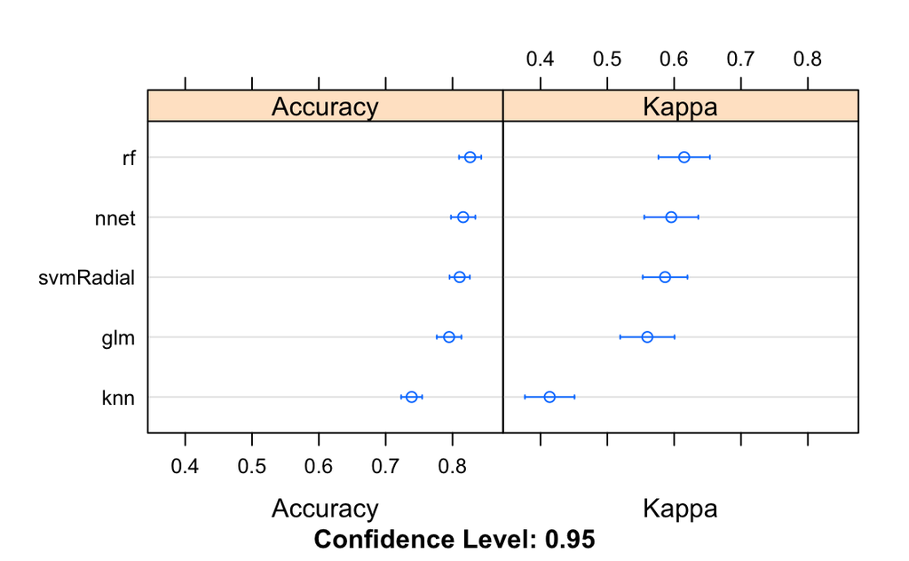

```r
dotplot(results)
```

```r
# correlation between results
modelCor(results)
```

```
                 rf       glm      nnet       knn svmRadial
rf        1.0000000 0.7368556 0.8641452 0.5412802 0.8951194
glm       0.7368556 1.0000000 0.7137516 0.2328386 0.6294181
nnet      0.8641452 0.7137516 1.0000000 0.4498516 0.8152864
knn       0.5412802 0.2328386 0.4498516 1.0000000 0.5421460
svmRadial 0.8951194 0.6294181 0.8152864 0.5421460 1.0000000
```

```r
stack.glm <- caretStack(models, method="gbm", metric="Accuracy", trControl=control)
```

```r
TrainMale<-subset(train2, train2$Sex=="male")
fit.gbmM <- train(Survived~Fsize+Embarked+Ticket.Freq+Age+Parch+SibSp+Pclass, data=TrainMale, method="gbm", metric=metric, trControl=control, verbose=FALSE)
```

```r
fit.gbm <- train(Survived~Fsize+Embarked+Ticket.Freq+Sex+Age+Parch+SibSp+Pclass, data=train2, method="gbm", metric=metric, trControl=control, verbose=FALSE)
```

```r
varImp(models)
```

```
Error in UseMethod("varImp") :
  no applicable method for 'varImp' applied to an object of class "caretList"
```

```r
#train2$isNA<-as.integer(is.na(train2$Age))
length(train2$isNA)
```

```
[1] 0
```

```r
#train2$Survived<-as.factor(train2$Survived)
train2$Cabin<-gsub('[[:digit:]]+', "",train2$Cabin)
train2$Cabin<-gsub('\\s+.*', "",train2$Cabin)
```

```r
train2$Cabin<-as.factor(train2$Cabin)
train2$HasNoCabin<-as.integer(is.na(train2$Cabin))
```

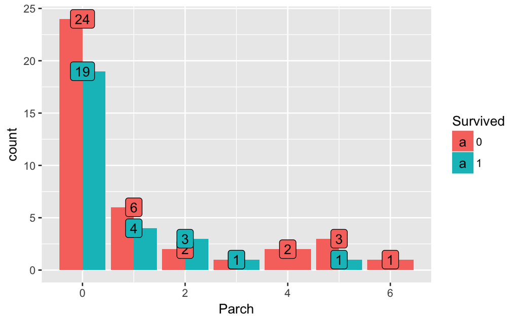

```r
#parch with female vs survived
ggplot(subset(train2, train2$Sex=="female" & train2$Age>=18 & train2$Survived!="NA" & train2$Pclass=="3"), aes(x=Parch, fill=Survived))+geom_bar(stat='Count',position = 'dodge')+theme_grey()+geom_label(stat='count', aes(label=..count..))
```

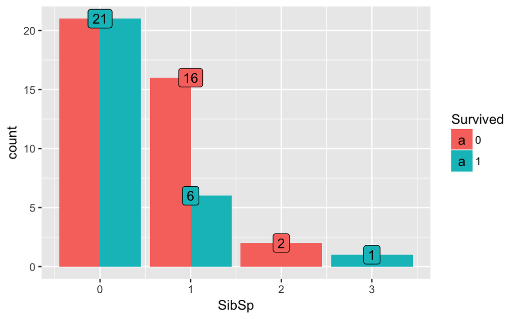

```r
#SibSp vs female
ggplot(subset(train2, train2$Sex=="female" & train2$Age>=18 & train2$Survived!="NA" & train2$Pclass=="3"), aes(x=SibSp, fill=Survived))+geom_bar(stat='Count',position = 'dodge')+theme_grey()+geom_label(stat='count', aes(label=..count..))
```

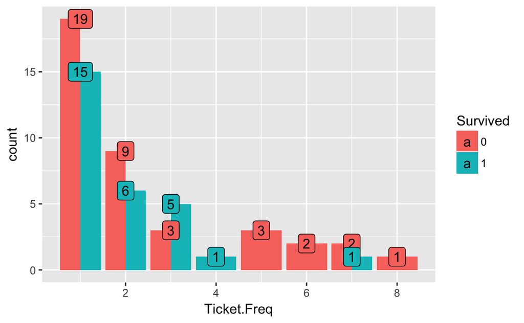

```r
#Pclass 3 female
ggplot(subset(train2, train2$Sex=="female" & train2$Age>=18 & train2$Pclass=="3" & train2$Survived!="NA"), aes(x=Ticket.Freq, fill=Survived))+geom_bar(stat='Count',position = 'dodge')+theme_grey()+geom_label(stat='count', aes(label=..count..))
```

```r
test3M<-subset(test3,test3$Sex=="male")
pred3<-predict(fit.gbmM,test3M)
predictionsMale3<-data.frame(test3M$PassengerId,pred3)
predictionsMale3$pred3<-as.numeric(predictionsMale3$pred3)
predictionsMale3$pred3<-sapply(predictionsMale3$pred3,function(x) x=x-1)
```

```r
pred<-predict(stack.glm,test2)
```

```
prediction from a rank-deficient fit may be misleading
```

```r
predictions<-data.frame(test2$PassengerId,pred)
predictions$pred<-as.numeric(predictions$pred)
predictions$pred<-sapply(predictions$pred,function(x) x=x-1)
colnames(predictions)<-c("PassengerId","Survived")
write.csv(predictions, file = "MyData.csv", row.names = FALSE)
```

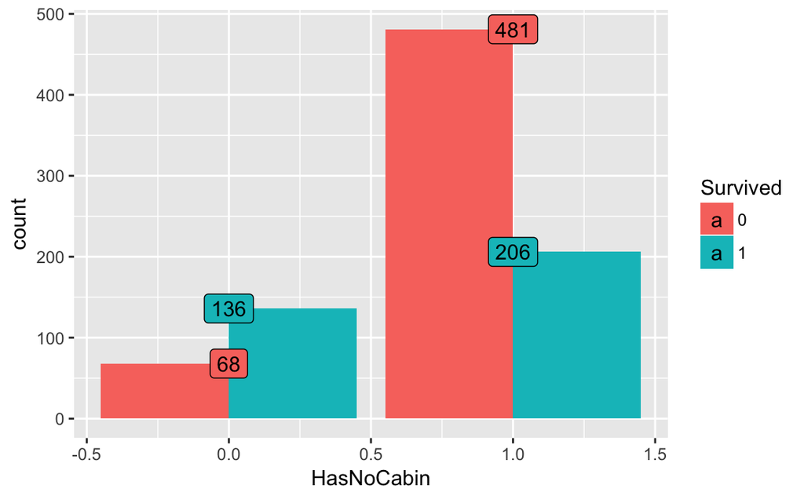

```r
#Cabin vs survived
ggplot(subset(train2, train2$Survived!="NA"), aes(x=HasNoCabin, fill=Survived))+geom_bar(stat='Count',position = 'dodge')+theme_grey()+geom_label(stat='count', aes(label=..count..))
```

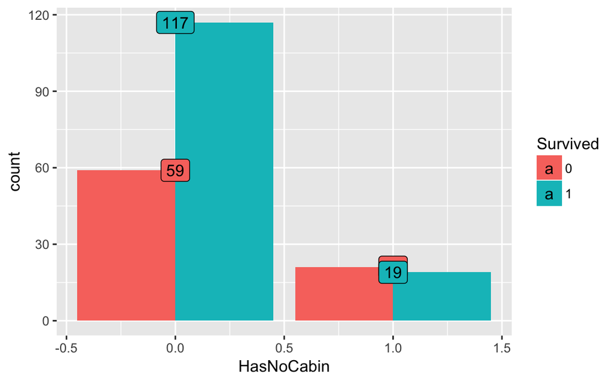

```r
#Cabin and in P1
ggplot(subset(train2, train2$Pclass=="1"  & train2$Survived!="NA"), aes(x=HasNoCabin, fill=Survived))+geom_bar(stat='Count',position = 'dodge')+theme_grey()+geom_label(stat='count', aes(label=..count..))
```

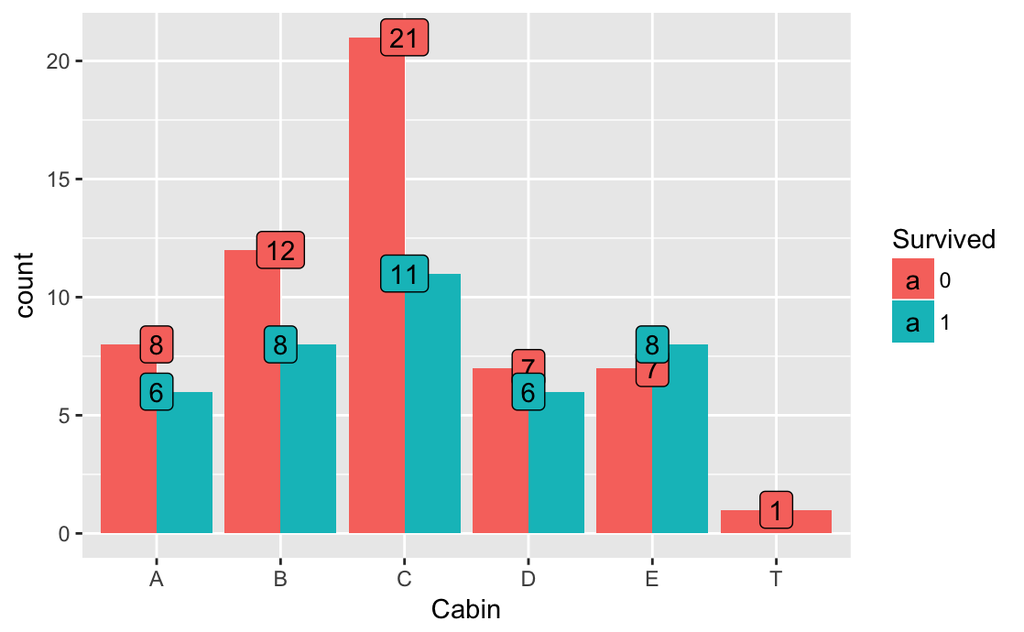

```r
ggplot(subset(train2,train2$HasNoCabin=="0" & train2$Sex=="male" & train2$Pclass=="1" & train2$Survived!="NA"), aes(x=Cabin, fill=Survived))+geom_bar(stat='Count',position = 'dodge')+theme_grey()+geom_label(stat='count', aes(label=..count..))
```

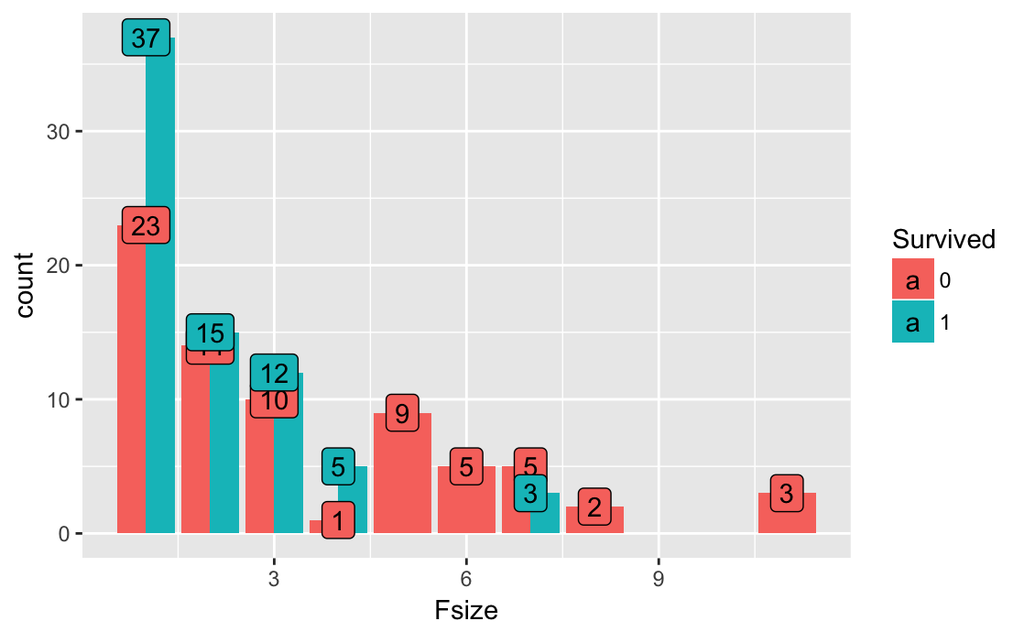

```r
ggplot(subset(train2,train2$Survived!="NA"  & train2$Sex=="female" & train2$Pclass=="3"), aes(x=Fsize, fill=Survived))+geom_bar(stat='Count',position = 'dodge')+theme_grey()+geom_label(stat='count', aes(label=..count..))
```

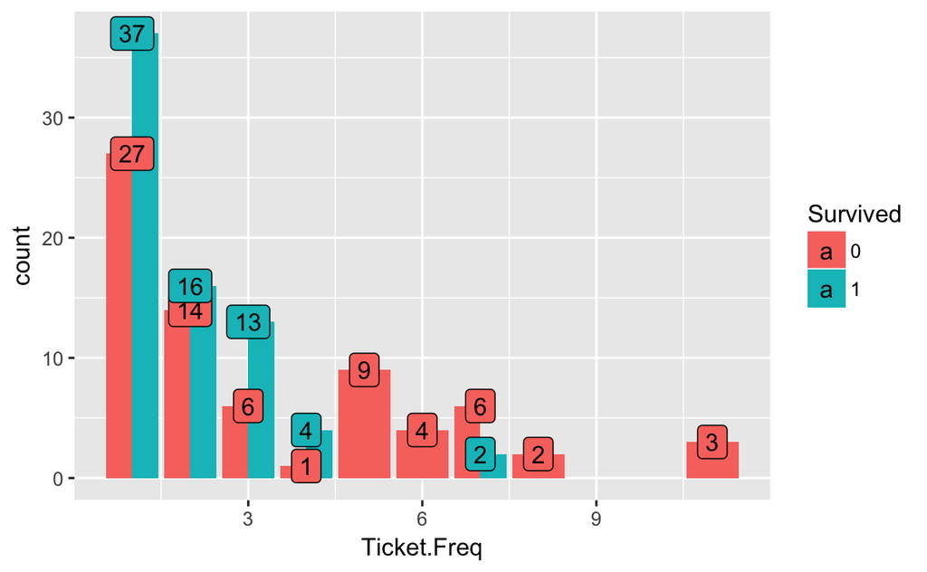

```r
#Ticket.Freq vs survived
ggplot(subset(train2,train2$Survived!="NA" & train2$Sex=="female" & train2$Pclass=="3"), aes(x=Ticket.Freq, fill=Survived))+geom_bar(stat='Count',position = 'dodge')+theme_grey()+geom_label(stat='count', aes(label=..count..))
```

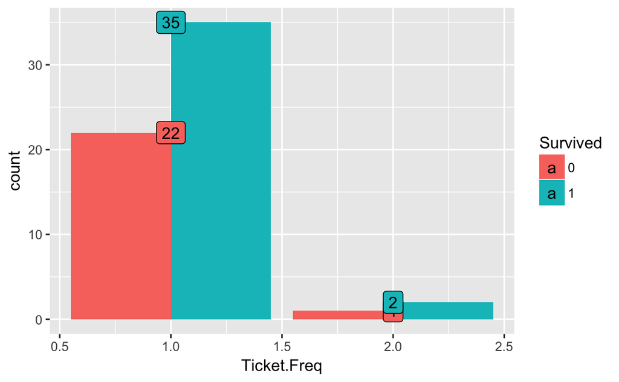

```r
ggplot(subset(train2,train2$Survived!="NA" & train2$Sex=="female" & train2$Pclass=="3" & train2$Fsize=="1"), aes(x=Ticket.Freq, fill=Survived))+geom_bar(stat='Count',position = 'dodge')+theme_grey()+geom_label(stat='count', aes(label=..count..))
```

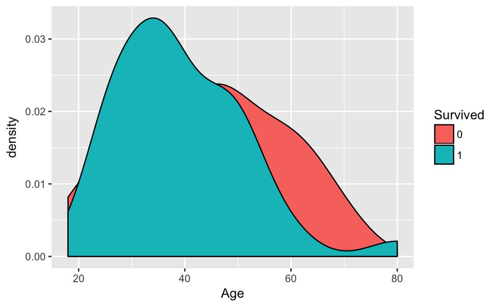

```r
ggplot(subset(train,train$Sex=="male" & train$Survived!="NA" & train$Pclass=="1" & train$Age>=18), aes(x=Age, fill=Survived)) +
  geom_density(position="identity")
```

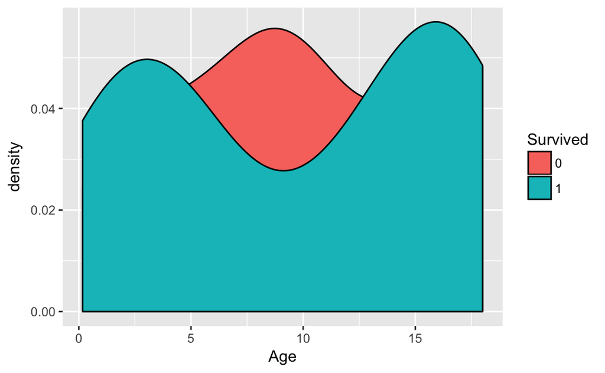

```r
ggplot(subset(train2,train2$Sex=="female" & train2$Survived!="NA" & train2$Pclass=="3" & train2$Age<=18), aes(x=Age, fill=Survived)) +
  geom_density(position="identity")
```

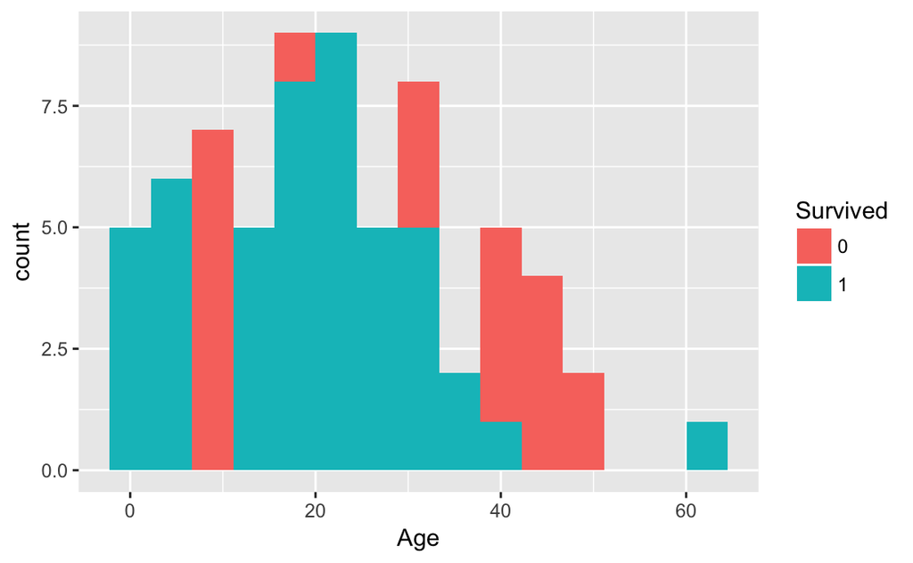

```r
ggplot(subset(train,train$Sex=="female" & train$Survived!="NA" & train$Pclass=="3"), aes(x=Age, fill=Survived)) +
  geom_histogram(position="identity", bins = 15)
```

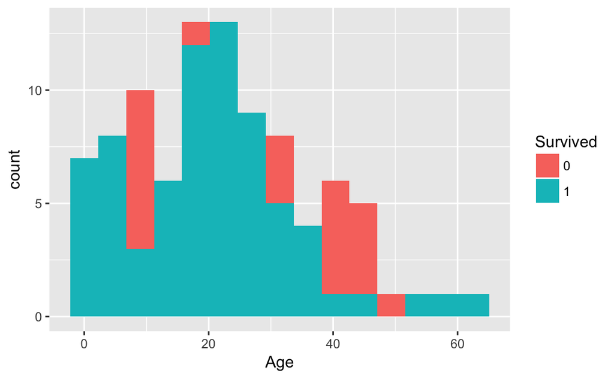

```r
ggplot(subset(train2,train2$Sex=="female" & train2$Survived!="NA" & train2$Pclass=="3"), aes(x=Age, fill=Survived)) +
  geom_histogram(position="identity", bins = 15)
```

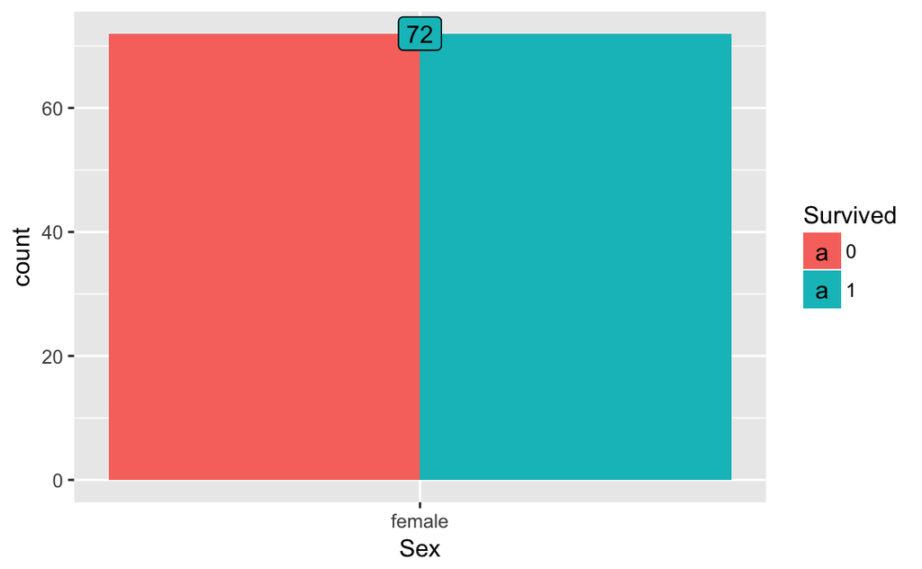

```r
ggplot(subset(train2,train2$Survived!="NA" & train2$Sex=="female" & train2$Pclass=="3"), aes(x=Sex, fill=Survived))+geom_bar(stat='Count',position = 'dodge')+theme_grey()+geom_label(stat='count', aes(label=..count..))
```

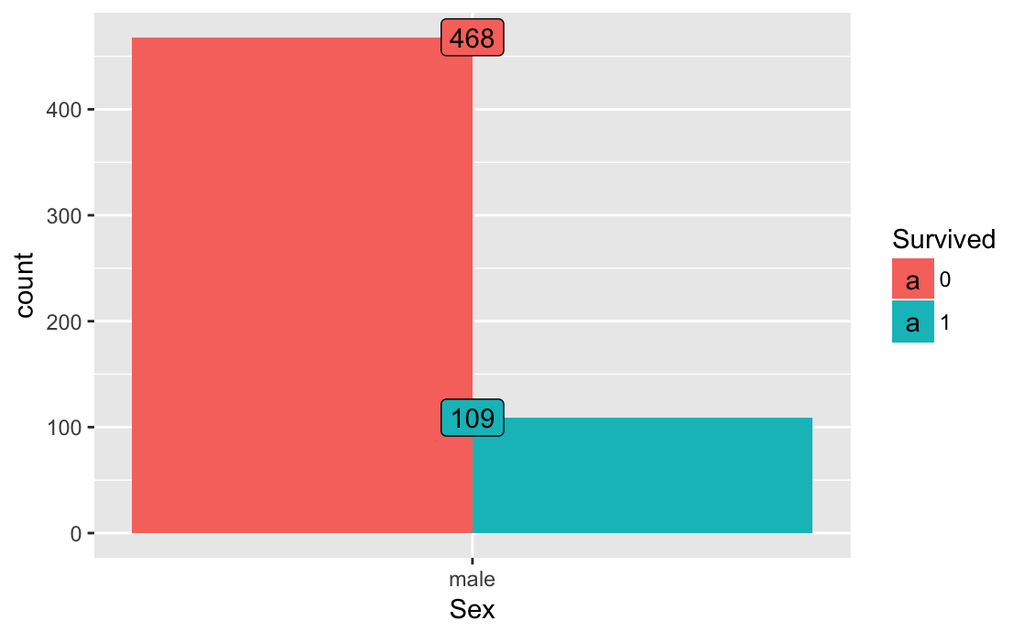

```r
ggplot(subset(train2,train2$Survived!="NA" & train2$Sex=="male"), aes(x=Sex, fill=Survived))+geom_bar(stat='Count',position = 'dodge')+theme_grey()+geom_label(stat='count', aes(label=..count..))
```

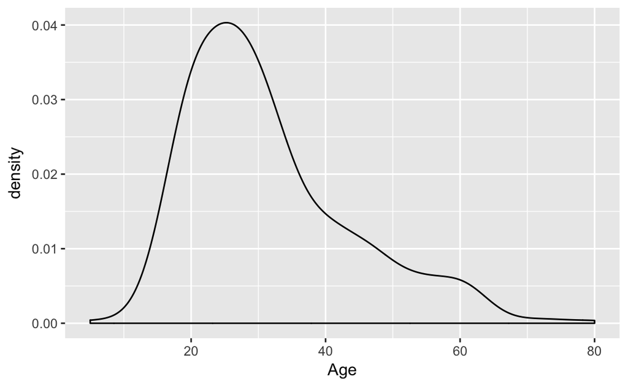

```r
ggplot(subset(train2,train2$Fsize=="1" & train$Survived!="NA"), aes(x=Age)) +
  geom_density(position="identity")
```

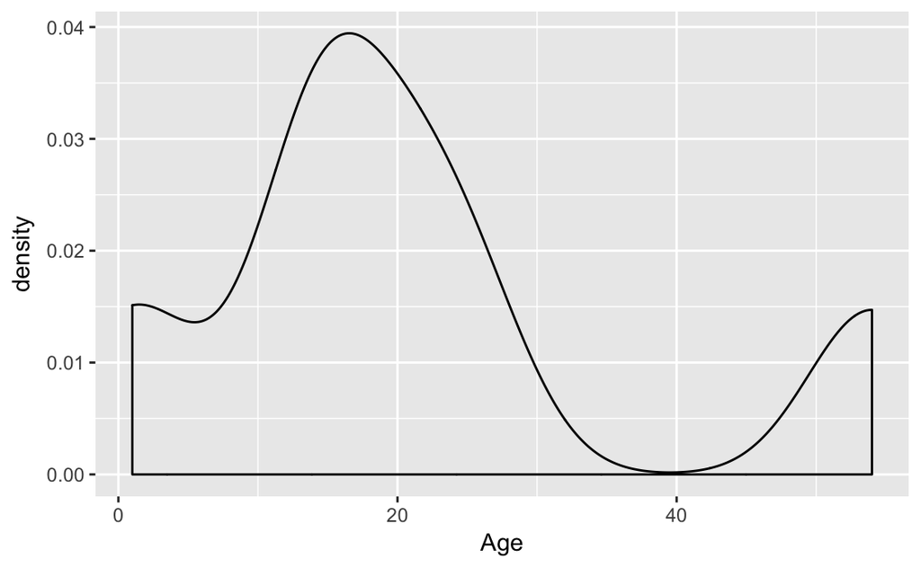

```r
ggplot(subset(train2,train2$SibSp=="1" & train$Survived!="NA" & train2$Title=="Miss" & train2$Ticket.Freq=="2"), aes(x=Age)) +
  geom_density(position="identity")
```

First I realized that fare is by ticket so one ticket for 2 people is 2x not by person.

```r
train2$FarePP<-train2$Fare/train2$Ticket.Freq
```

Imputing missing embarked. Ran t-tests based on my own hypothesis that fare was due to embarked and Pclass. The results back my hypothesis that there is a difference in fare base on embarked and pclass. Now the two missing embarked were from Pclass 1.Also, there are only two entries for Q and Pclass equals 1 so it cannot be from class Q. Now given the results I can say that it is most likely in class S

```r
t.test(subset(train2$FarePP,train2$Embarked=="S" & train2$Pclass=="1" ),subset(train2$FarePP,train2$Embarked=="C" & train2$Pclass=="1"))
```

```
    Welch Two Sample t-test

data:  subset(train2$FarePP, train2$Embarked == "S" & train2$Pclass ==  and subset(train2$FarePP, train2$Embarked == "C" & train2$Pclass ==     "1") and     "1")
t = -3.8263, df = 127.32, p-value = 0.0002029
alternative hypothesis: true difference in means is not equal to 0
95 percent confidence interval:
 -26.198305  -8.337773
sample estimates:
mean of x mean of y
 36.74855  54.01658
```

```r
t.test(subset(train2$FarePP,train2$Embarked=="C" & train2$Pclass=="1"))
```

```
    One Sample t-test

data:  subset(train2$FarePP, train2$Embarked == "C" & train2$Pclass ==     "1")
t = 13.426, df = 84, p-value < 2.2e-16
alternative hypothesis: true mean is not equal to 0
95 percent confidence interval:
 46.01563 62.01754
sample estimates:
mean of x
 54.01658
```

```r
t.test(subset(train2$FarePP,train2$Embarked=="S" & train2$Pclass=="1"))
```

```
    One Sample t-test

data:  subset(train2$FarePP, train2$Embarked == "S" & train2$Pclass ==     "1")
t = 17.975, df = 126, p-value < 2.2e-16
alternative hypothesis: true mean is not equal to 0
95 percent confidence interval:
 32.70263 40.79446
sample estimates:
mean of x
 36.74855
```

```r
train2$Embarked[train2$Ticket=='113572']<-"S"
```

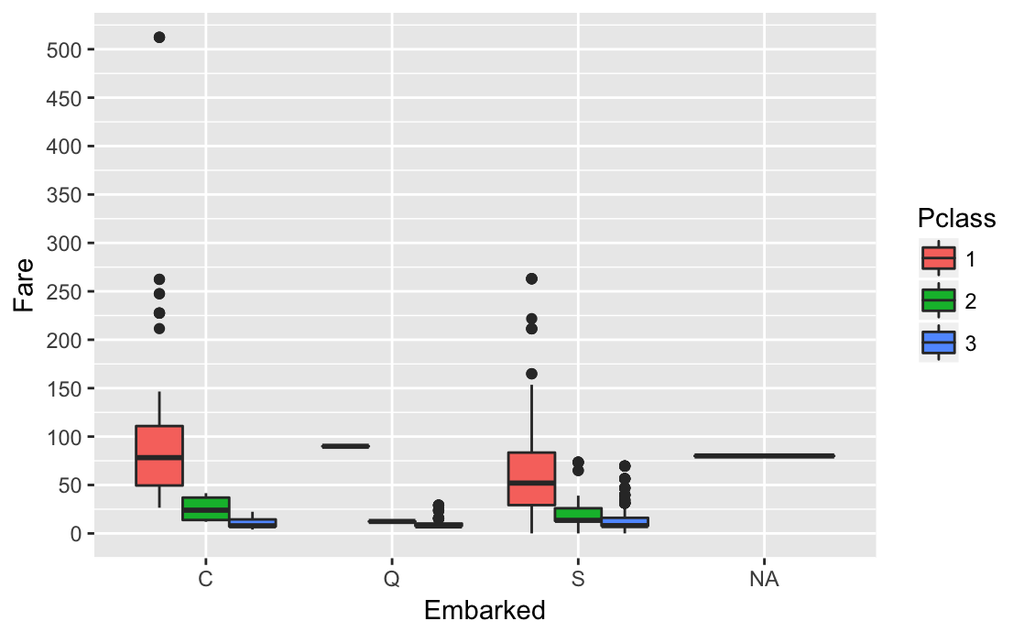

```r
ggplot(train2, aes(x = Embarked, y = Fare, fill=Pclass )) +
    geom_boxplot() + scale_y_continuous(breaks = scales::pretty_breaks(n = 10)) + theme_grey()
```

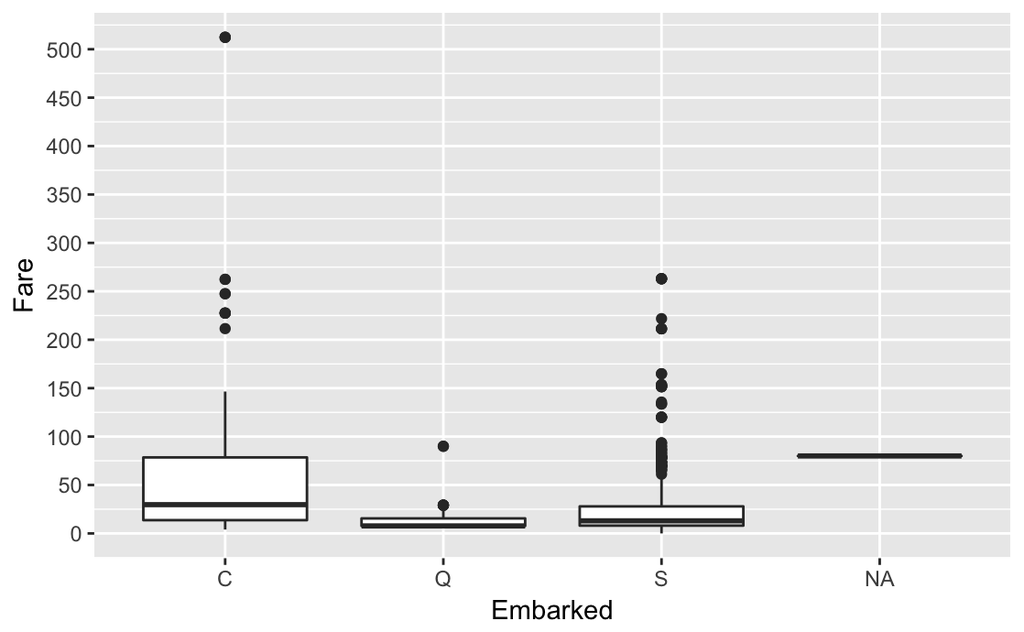

```r
ggplot(train2, aes(x = Embarked, y = Fare)) +
    geom_boxplot() + scale_y_continuous(breaks = scales::pretty_breaks(n = 10)) + theme_grey()
```

```r
analyze<-function(x){
  chisq.test(table(train2$isNA,x))}
```

```r
TestForMissingAtRandom<-lapply(train2, function(x) if(is.integer(x)){analyze(x)})
```

```
Chi-squared approximation may be incorrectChi-squared approximation may be incorrect
```

```r
print(TestForMissingAtRandom)
```

[output not shown]

```r
imp<-mice(train2[c(-1,-2,-4,-12,-13)],m=5, method='pmm', seed=5565)
```

```
Number of logged events: 1
```

```r
data2<-complete(imp,action='all')
fit <- with(data = imp, lm(Age~Title+Sex+Pclass+Embarked+SibSp+Parch+Fare))
summary(pool(fit))
```

[output not shown]